# PCA Model

**CTL vs AD:**  
19 probes pass the epigenome-wide significance threshold of 2.4x10-7  
*The top 50 CTL vs AD associated DMPs:*

| ProbeID | Position | F | p (F) | FDR.Anova | Difference | CI lower | CI upper | pCvM | FDR | Difference | CI lower | CI upper | pCvA | FDR | Difference | CI lower | CI upper | pMvA | FDR | UCSC Gene | UCSC Gene Group | UCSC Relation to CpG Island | Gene Closest TSS | Distance Closest TSS | GREAT Annotation 1 | GREAT Annotation 2 |
| --- | --- | --- | --- | --- | --- | --- | --- | --- | --- | --- | --- | --- | --- | --- | --- | --- | --- | --- | --- | --- | --- | --- | --- | --- | --- | --- |
| cg22822140 | chr X: 153046577 | 58.689 | 4.97e-20 | 4.80e-16 | -0.009 | -0.031 | 0.014 | 0.62 | 1 | -0.093 | -0.116 | -0.071 | 4.95e-14 | 1.51e-10 | -0.085 | -0.107 | -0.062 | 5.05e-14 | 1.68e-10 | SRPK3;SRPK3;SRPK3 | 1stExon;1stExon;1stExon | Island | SRPK3 | 122 | SRPK3 (122) | (NA) |
| cg24496423 | chr X: 153046480 | 52.902 | 1.60e-18 | 7.70e-15 | 0.001 | -0.017 | 0.02 | 0.985 | 1 | -0.070 | -0.088 | -0.051 | 5.50e-14 | 1.51e-10 | -0.071 | -0.089 | -0.052 | 5.01e-14 | 1.68e-10 | SRPK3;SRPK3;SRPK3;SRPK3;SRPK3;SRPK3 | 5'UTR;1stExon;1stExon;5'UTR;5'UTR;1stExon | Island | SRPK3 | 25 | SRPK3 (25) | (NA) |
| cg12468189 | chr X: 153046767 | 37.891 | 2.70e-14 | 6.51e-11 | -0.025 | -0.04 | -0.01 | 2.46e-04 | 0.015 | -0.055 | -0.069 | -0.040 | 5.91e-14 | 1.51e-10 | -0.03 | -0.044 | -0.015 | 1.07e-05 | 0.004 | SRPK3;SRPK3;SRPK3 | Body;Body;Body | Island | SRPK3 | 312 | SRPK3 (312) | (NA) |
| cg12230162 | chr X: 153046482 | 51.309 | 4.26e-18 | 1.37e-14 | 0.001 | -0.023 | 0.025 | 0.994 | 1 | -0.090 | -0.114 | -0.065 | 6.25e-14 | 1.51e-10 | -0.091 | -0.115 | -0.067 | 5.23e-14 | 1.68e-10 | SRPK3;SRPK3;SRPK3;SRPK3;SRPK3;SRPK3 | 5'UTR;1stExon;1stExon;5'UTR;5'UTR;1stExon | Island | SRPK3 | 27 | SRPK3 (27) | (NA) |
| cg16529483 | chr X: 153046451 | 32.495 | 1.20e-12 | 1.93e-09 | -0.012 | -0.037 | 0.012 | 0.462 | 1 | -0.078 | -0.103 | -0.054 | 1.35e-11 | 2.60e-08 | -0.066 | -0.091 | -0.042 | 4.55e-09 | 4.88e-06 | SRPK3;SRPK3;SRPK3 | TSS200;TSS200;TSS200 | Island | SRPK3 | -4 | SRPK3 (-4) | (NA) |
| cg17405188 | chr X: 73164102 | 27.342 | 5.35e-11 | 4.69e-08 | 0.009 | 0.004 | 0.014 | 3.33e-04 | 0.019 | 0.017 | 0.012 | 0.023 | 1.99e-11 | 3.20e-08 | 0.008 | 0.003 | 0.013 | 0.001 | 0.11 | LOC554203 | TSS200 | Island | JPX | -56 | ZCCHC13 (-359922) | CHIC1 (381119) |
| cg19938385 | chr X: 107020894 | 28.842 | 1.74e-11 | 1.68e-08 | -0.048 | -0.066 | -0.029 | 1.35e-08 | 1.28e-05 | -0.054 | -0.073 | -0.036 | 2.40e-10 | 3.31e-07 | -0.007 | -0.025 | 0.012 | 0.673 | 1 |  |  | S_Shore | TSC22D3 | -1692 | TSC22D3 (-1878) | (NA) |
| cg23914849 | chr X: 52950051 | 22.164 | 2.90e-09 | 1.40e-06 | 0.004 | 0.002 | 0.006 | 2.76e-04 | 0.016 | 0.006 | 0.004 | 0.008 | 1.42e-09 | 1.71e-06 | 0.003 | 3.23e-04 | 0.005 | 0.02 | 0.465 |  |  | Island | FAM156A | 13799 | FAM156B (21967) | FAM156A (74599) |
| cg09661041 | chr X: 153141905 | 25.095 | 2.96e-10 | 2.04e-07 | -0.005 | -0.027 | 0.018 | 0.867 | 1 | -0.061 | -0.083 | -0.038 | 6.39e-09 | 6.85e-06 | -0.056 | -0.078 | -0.034 | 4.96e-08 | 3.42e-05 | L1CAM;L1CAM;L1CAM | TSS1500;TSS1500;TSS1500 |  | L1CAM | -506 | L1CAM (-507) | (NA) |
| cg07344627 | chr X: 125687011 | 19.773 | 1.96e-08 | 5.92e-06 | -0.033 | -0.057 | -0.01 | 0.003 | 0.077 | -0.063 | -0.087 | -0.039 | 8.22e-09 | 7.93e-06 | -0.03 | -0.053 | -0.006 | 0.009 | 0.317 | DCAF12L1 | TSS200 | S_Shore | DCAF12L1 | -169 | DCAF12L1 (-170) | (NA) |
| cg09768654 | chr X: 153046386 | 29.595 | 9.96e-12 | 1.25e-08 | 0.008 | -0.015 | 0.031 | 0.689 | 1 | -0.060 | -0.083 | -0.037 | 1.62e-08 | 1.42e-05 | -0.068 | -0.09 | -0.045 | 1.08e-10 | 1.74e-07 | SRPK3;SRPK3;SRPK3 | TSS200;TSS200;TSS200 | Island | SRPK3 | -69 | SRPK3 (-69) | (NA) |
| cg21364342 | chr X: 107226611 | 22.082 | 3.10e-09 | 1.42e-06 | -0.022 | -0.031 | -0.012 | 6.39e-07 | 2.28e-04 | -0.025 | -0.034 | -0.015 | 2.36e-08 | 1.83e-05 | -0.003 | -0.012 | 0.006 | 0.734 | 1 | TEX13B | TSS1500 |  | TEX13B | -1011 | VSIG1 (-61588) | MID2 (157528) |
| cg22574818 | chr X: 55479616 | 18.371 | 6.15e-08 | 1.34e-05 | -0.033 | -0.056 | -0.01 | 0.002 | 0.073 | -0.059 | -0.083 | -0.036 | 2.76e-08 | 1.83e-05 | -0.026 | -0.049 | -0.004 | 0.019 | 0.454 | MAGEH1;MAGEH1 | 1stExon;3'UTR |  | MAGEH1 | 1079 | MAGEH1 (1079) | USP51 (36014) |
| cg04768884 | chr X: 19443172 | 20.438 | 1.15e-08 | 3.82e-06 | 0.008 | -0.006 | 0.022 | 0.394 | 1 | 0.036 | 0.022 | 0.050 | 2.81e-08 | 1.83e-05 | 0.028 | 0.015 | 0.042 | 8.70e-06 | 0.003 | MAP3K15 | Body |  | MAP3K15 | 35099 | PDHA1 (81162) | MAP3K15 (90206) |
| cg04710661 | chr X: 2848381 | 18.505 | 5.51e-08 | 1.24e-05 | 0.007 | 3.61e-04 | 0.014 | 0.036 | 0.359 | 0.018 | 0.011 | 0.024 | 2.85e-08 | 1.83e-05 | 0.01 | 0.004 | 0.017 | 0.001 | 0.092 | ARSD;ARSD | TSS1500;TSS1500 | S_Shore | ARSD | -965 | ARSD (-966) | (NA) |
| cg06068202 | chr X: 150343148 | 20.237 | 1.35e-08 | 4.21e-06 | 0.040 | 0.021 | 0.058 | 3.14e-06 | 6.45e-04 | 0.047 | 0.028 | 0.066 | 6.05e-08 | 3.65e-05 | 0.007 | -0.011 | 0.026 | 0.637 | 1 |  |  | Island | GPR50 | -1907 | GPR50 (-1907) | (NA) |
| cg00123001 | chr X: 13395880 | 21.825 | 3.80e-09 | 1.67e-06 | -0.019 | -0.027 | -0.011 | 1.99e-07 | 8.75e-05 | -0.020 | -0.028 | -0.012 | 8.47e-08 | 4.81e-05 | -8.44e-04 | -0.009 | 0.007 | 0.966 | 1 |  |  | N_Shore | LOC100133123 | 42521 | EGFL6 (-191813) | ATXN3L (-57363) |
| cg26101161 | chr X: 122736584 | 19.255 | 2.99e-08 | 8.23e-06 | -0.020 | -0.03 | -0.011 | 4.18e-06 | 7.75e-04 | -0.024 | -0.033 | -0.014 | 1.51e-07 | 8.08e-05 | -0.003 | -0.013 | 0.006 | 0.715 | 1 | THOC2 | 3'UTR |  | THOC2 | 8230 | THOC2 (130319) | GRIA3 (418489) |
| cg00072799 | chr X: 78427682 | 17.814 | 9.71e-08 | 1.99e-05 | -0.007 | -0.021 | 0.007 | 0.485 | 1 | -0.033 | -0.047 | -0.019 | 2.33e-07 | 1.18e-04 | -0.027 | -0.04 | -0.013 | 2.85e-05 | 0.008 | GPR174;GPR174 | 1stExon;3'UTR |  | GPR174 | 1214 | GPR174 (1214) | ITM2A (195366) |
| cg01975035 | chr X: 24761808 | 15.399 | 7.28e-07 | 1.06e-04 | -0.012 | -0.023 | -0.002 | 0.017 | 0.24 | -0.025 | -0.036 | -0.014 | 3.31e-07 | 1.51e-04 | -0.013 | -0.023 | -0.002 | 0.013 | 0.367 | SCARNA23;POLA1 | TSS1500;Body |  | SCARNA23 | -749 | POLA1 (49745) | ARX (272256) |
| cg00805156 | chr X: 3264341 | 18.808 | 4.30e-08 | 1.08e-05 | 0.036 | 0.019 | 0.052 | 2.90e-06 | 6.08e-04 | 0.040 | 0.023 | 0.056 | 3.38e-07 | 1.51e-04 | 0.004 | -0.013 | 0.02 | 0.856 | 1 | MXRA5 | 5'UTR | Island | MXRA5 | 343 | MXRA5 (342) | (NA) |
| cg02329520 | chr X: 153740317 | 17.039 | 1.84e-07 | 3.48e-05 | -0.014 | -0.022 | -0.007 | 5.43e-05 | 0.005 | -0.018 | -0.026 | -0.010 | 3.45e-07 | 1.51e-04 | -0.004 | -0.011 | 0.004 | 0.452 | 1 | FAM3A;FAM3A;FAM3A;FAM3A;FAM3A | Body;Body;Body;Body;Body | N_Shelf | FAM3A | 4249 | SLC10A3 (-21316) | FAM3A (4248) |
| cg06616051 | chr X: 153094332 | 15.212 | 8.53e-07 | 1.21e-04 | 0.019 | 6.98e-04 | 0.036 | 0.04 | 0.38 | 0.042 | 0.024 | 0.060 | 4.18e-07 | 1.75e-04 | 0.023 | 0.006 | 0.041 | 0.006 | 0.253 | PDZD4 | Body | Island | PDZD4 | 1019 | IDH3G (-34366) | PDZD4 (1670) |
| cg00928753 | chr X: 36976515 | 15.226 | 8.43e-07 | 1.21e-04 | 0.021 | -1.70e-04 | 0.042 | 0.052 | 0.439 | 0.049 | 0.028 | 0.070 | 4.35e-07 | 1.75e-04 | 0.028 | 0.008 | 0.049 | 0.004 | 0.209 |  |  | S_Shore | FAM47C | -49916 | PRRG1 (-232012) | CXorf59 (911463) |
| cg25549901 | chr X: 137951118 | 21.139 | 6.55e-09 | 2.62e-06 | -0.027 | -0.037 | -0.016 | 8.19e-08 | 4.39e-05 | -0.025 | -0.036 | -0.014 | 5.36e-07 | 2.03e-04 | 0.001 | -0.009 | 0.012 | 0.946 | 1 | FGF13;FGF13;FGF13;FGF13 | 5'UTR;Body;TSS1500;Body |  | FGF13 | -1401 | FGF13 (336066) | (NA) |
| cg07865294 | chr X: 30248557 | 14.865 | 1.14e-06 | 1.56e-04 | 0.026 | 0.002 | 0.05 | 0.033 | 0.344 | 0.056 | 0.032 | 0.080 | 5.47e-07 | 2.03e-04 | 0.03 | 0.006 | 0.054 | 0.009 | 0.316 | MAGEB3;MAGEB3 | 1stExon;5'UTR |  | MAGEB3 | 5 | NR0B1 (78937) | (NA) |
| cg08850124 | chr X: 118207749 | 16.302 | 3.41e-07 | 5.86e-05 | -0.013 | -0.02 | -0.006 | 8.85e-05 | 0.007 | -0.016 | -0.023 | -0.009 | 5.84e-07 | 2.05e-04 | -0.004 | -0.01 | 0.003 | 0.446 | 1 |  |  | Island | KIAA1210 | 76793 | PGRMC1 (-162461) | LONRF3 (99037) |
| cg20814574 | chr X: 92928640 | 14.996 | 1.02e-06 | 1.41e-04 | 0.005 | -5.67e-04 | 0.01 | 0.089 | 0.565 | 0.013 | 0.007 | 0.018 | 6.03e-07 | 2.05e-04 | 0.008 | 0.002 | 0.013 | 0.003 | 0.158 | FAM133A;FAM133A;NAP1L3;FAM133A;FAM133A | TSS1500;TSS1500;TSS200;TSS1500;TSS1500 | Island | NAP1L3 | 42 | NAP1L3 (41) | (NA) |
| ch.X.1639000R | chr X: 113225430 | 14.841 | 1.17e-06 | 1.56e-04 | 0.010 | 0.003 | 0.017 | 0.004 | 0.1 | 0.016 | 0.009 | 0.023 | 6.17e-07 | 2.05e-04 | 0.007 | -3.45e-04 | 0.014 | 0.066 | 0.831 |  |  |  | HTR2C | -593120 | HTR2C (-593120) | (NA) |
| cg24352688 | chr X: 13751727 | 16.997 | 1.91e-07 | 3.48e-05 | 0.002 | -0.004 | 0.009 | 0.692 | 1 | 0.016 | 0.009 | 0.023 | 7.40e-07 | 2.38e-04 | 0.013 | 0.007 | 0.02 | 1.98e-05 | 0.006 | TRAPPC2;OFD1;TRAPPC2;TRAPPC2 | 5'UTR;TSS1500;5'UTR;5'UTR | N_Shore | TRAPPC2 | 1027 | OFD1 (-1104) | TRAPPC2 (1026) |
| cg12039689 | chr X: 153141750 | 15.076 | 9.57e-07 | 1.34e-04 | -0.016 | -0.037 | 0.006 | 0.193 | 0.814 | -0.049 | -0.071 | -0.027 | 7.92e-07 | 2.47e-04 | -0.033 | -0.054 | -0.012 | 8.18e-04 | 0.078 | L1CAM;L1CAM;L1CAM | TSS1500;TSS1500;TSS1500 |  | L1CAM | -351 | L1CAM (-352) | (NA) |
| cg16170760 | chr X: 153708103 | 14.304 | 1.84e-06 | 2.25e-04 | -0.007 | -0.015 | 7.76e-04 | 0.085 | 0.553 | -0.018 | -0.027 | -0.010 | 1.05e-06 | 3.16e-04 | -0.011 | -0.019 | -0.003 | 0.004 | 0.205 | LAGE3 | TSS1500 | S_Shore | LAGE3 | -507 | LAGE3 (-508) | (NA) |
| cg00779763 | chr X: 47479114 | 14.682 | 1.34e-06 | 1.76e-04 | 0.007 | -0.003 | 0.018 | 0.233 | 0.89 | 0.024 | 0.013 | 0.035 | 1.21e-06 | 3.52e-04 | 0.017 | 0.006 | 0.027 | 7.78e-04 | 0.075 | SYN1;SYN1 | 1stExon;1stExon | Island | SYN1 | 142 | SYN1 (141) | (NA) |
| cg02754763 | chr X: 44403388 | 16.283 | 3.46e-07 | 5.86e-05 | -0.002 | -0.009 | 0.005 | 0.791 | 1 | -0.016 | -0.023 | -0.009 | 1.67e-06 | 4.74e-04 | -0.014 | -0.021 | -0.007 | 2.06e-05 | 0.006 | FUNDC1 | TSS1500 |  | FUNDC1 | -1167 | DUSP21 (-299860) | EFHC2 (-200466) |
| cg14403309 | chr X: 37213086 | 13.346 | 4.20e-06 | 4.02e-04 | -0.016 | -0.03 | -0.003 | 0.014 | 0.206 | -0.030 | -0.044 | -0.016 | 2.07e-06 | 5.68e-04 | -0.014 | -0.027 | -1.30e-04 | 0.047 | 0.714 | PRRG1;PRRG1 | 5'UTR;5'UTR | S_Shelf | PRRG1 | 4504 | LANCL3 (-217735) | PRRG1 (4559) |
| cg27250462 | chr X: 119250508 | 13.253 | 4.55e-06 | 4.14e-04 | -0.009 | -0.018 | -7.31e-04 | 0.03 | 0.324 | -0.019 | -0.027 | -0.010 | 2.19e-06 | 5.68e-04 | -0.009 | -0.018 | -0.001 | 0.023 | 0.495 | RHOXF1 | TSS1500 | S_Shore | RHOXF1 | -661 | RHOXF1 (-662) | (NA) |
| ch.X.42921571R | chr X: 43036627 | 14.035 | 2.32e-06 | 2.61e-04 | 0.008 | 0.003 | 0.014 | 8.23e-04 | 0.035 | 0.012 | 0.006 | 0.017 | 2.20e-06 | 5.68e-04 | 0.003 | -0.002 | 0.009 | 0.288 | 1 |  |  |  | AK056105 | 385 | MAOA (-478781) | PPP1R2P9 (-399142) |
| cg21179255 | chr X: 152772707 | 13.239 | 4.60e-06 | 4.15e-04 | -0.014 | -0.026 | -0.002 | 0.018 | 0.24 | -0.026 | -0.038 | -0.014 | 2.24e-06 | 5.68e-04 | -0.012 | -0.024 | -4.73e-04 | 0.039 | 0.659 | BGN | Body |  | HAUS7 | -11729 | ATP2B3 (-28872) | BGN (12361) |
| cg16122592 | chr X: 26210712 | 22.264 | 2.68e-09 | 1.36e-06 | -0.030 | -0.042 | -0.019 | 8.00e-09 | 9.64e-06 | -0.025 | -0.036 | -0.013 | 2.40e-06 | 5.95e-04 | 0.005 | -0.006 | 0.017 | 0.514 | 1 | MAGEB6 | 5'UTR |  | MAGEB6 | 156 | MAGEB6 (156) | (NA) |
| cg22964346 | chr X: 109411307 | 14.005 | 2.38e-06 | 2.64e-04 | -0.008 | -0.013 | -0.003 | 6.51e-04 | 0.03 | -0.011 | -0.016 | -0.006 | 2.51e-06 | 6.05e-04 | -0.003 | -0.008 | 0.002 | 0.335 | 1 | TMEM164;TMEM164 | Body;Body |  | SNORD96B | 56981 | AMMECR1 (150072) | TMEM164 (164966) |
| cg02048654 | chr X: 132551786 | 12.916 | 6.09e-06 | 5.15e-04 | 0.026 | -7.43e-04 | 0.053 | 0.059 | 0.464 | 0.058 | 0.031 | 0.086 | 3.11e-06 | 7.32e-04 | 0.032 | 0.005 | 0.059 | 0.014 | 0.375 |  |  | S_Shore | GPC4 | -2581 | GPC4 (-2582) | (NA) |
| cg25896901 | chr X: 125300481 | 20.804 | 8.57e-09 | 3.08e-06 | 0.009 | -0.016 | 0.035 | 0.653 | 1 | -0.055 | -0.081 | -0.029 | 3.54e-06 | 8.13e-04 | -0.065 | -0.09 | -0.039 | 3.28e-08 | 2.51e-05 | DCAF12L2 | TSS1500 | S_Shore | DCAF12L2 | -401 | DCAF12L1 (386360) | (NA) |
| cg19002579 | chr X: 21776218 | 13.256 | 4.53e-06 | 4.14e-04 | 0.045 | 0.015 | 0.075 | 0.002 | 0.055 | 0.065 | 0.034 | 0.095 | 3.82e-06 | 8.38e-04 | 0.02 | -0.01 | 0.05 | 0.263 | 1 | SMPX;SMPX | 1stExon;5'UTR |  | SMPX | 60 | SMPX (59) | (NA) |
| cg01988541 | chr X: 125683904 | 13.122 | 5.09e-06 | 4.39e-04 | -0.013 | -0.022 | -0.004 | 0.002 | 0.067 | -0.019 | -0.028 | -0.010 | 3.94e-06 | 8.38e-04 | -0.006 | -0.015 | 0.003 | 0.23 | 1 | DCAF12L1 | 3'UTR | N_Shore | DCAF12L1 | 2687 | DCAF12L1 (2937) | (NA) |
| cg17413784 | chr X: 139437320 | 13.926 | 2.55e-06 | 2.76e-04 | 0.045 | 0.018 | 0.072 | 3.11e-04 | 0.018 | 0.058 | 0.031 | 0.085 | 3.97e-06 | 8.38e-04 | 0.013 | -0.014 | 0.04 | 0.506 | 1 |  |  |  | U7 | -95992 | CXorf66 (-389644) | SOX3 (149904) |
| ch.X.94051109R | chr X: 94164453 | 15.574 | 6.28e-07 | 9.62e-05 | 0.008 | 0.004 | 0.012 | 1.83e-05 | 0.002 | 0.009 | 0.005 | 0.013 | 4.04e-06 | 8.38e-04 | 7.24e-04 | -0.003 | 0.005 | 0.912 | 1 |  |  |  | Mir_548 | 153771 | NONE (NA) | (NA) |
| cg14736837 | chr X: 15333837 | 13.379 | 4.08e-06 | 3.98e-04 | -0.018 | -0.03 | -0.007 | 9.68e-04 | 0.039 | -0.025 | -0.037 | -0.013 | 4.08e-06 | 8.38e-04 | -0.007 | -0.019 | 0.005 | 0.334 | 1 | ASB11;ASB11 | TSS1500;TSS200 |  | ASB11 | -91 | ASB11 (-92) | (NA) |
| cg13492609 | chr X: 151308320 | 12.348 | 9.97e-06 | 7.34e-04 | -0.009 | -0.019 | 2.57e-04 | 0.058 | 0.462 | -0.021 | -0.030 | -0.011 | 5.09e-06 | 0.001 | -0.011 | -0.021 | -0.002 | 0.019 | 0.454 | MAGEA10;MAGEA10 | TSS1500;TSS1500 |  | MAGEA10 | -1270 | MAGEA5 (-21910) | GABRA3 (311510) |
| cg20784188 | chr X: 44703983 | 14.557 | 1.49e-06 | 1.84e-04 | -0.003 | -0.013 | 0.007 | 0.769 | 1 | -0.022 | -0.032 | -0.011 | 5.29e-06 | 0.001 | -0.019 | -0.029 | -0.009 | 7.11e-05 | 0.015 | DUSP21;DUSP21 | 3'UTR;1stExon | S_Shore | DUSP21 | 735 | DUSP21 (735) | (NA) |
| cg23247524 | chr X: 35816354 | 12.883 | 6.26e-06 | 5.25e-04 | -0.025 | -0.042 | -0.009 | 0.001 | 0.044 | -0.035 | -0.051 | -0.018 | 6.43e-06 | 0.001 | -0.009 | -0.026 | 0.007 | 0.364 | 1 | MAGEB16 | TSS200 |  | MAGEB16 | -104 | CXorf59 (-248698) | (NA) |

**MCI vs AD:**  
16 probes pass the epigenome-wide significance threshold of 2.4x10-7

*The top 50 MCI vs AD associated DMPs:*

| ProbeID | Position | F | p (F) | FDR.Anova | Difference | CI lower | CI upper | pCvM | FDR | Difference | CI lower | CI upper | pCvA | FDR | Difference | CI lower | CI upper | pMvA | FDR | UCSC Gene | UCSC Gene Group | UCSC Relation to CpG Island | Gene Closest TSS | Distance Closest TSS | GREAT Annotation 1 | GREAT Annotation 2 |
| --- | --- | --- | --- | --- | --- | --- | --- | --- | --- | --- | --- | --- | --- | --- | --- | --- | --- | --- | --- | --- | --- | --- | --- | --- | --- | --- |
| cg24496423 | chr X: 153046480 | 52.902 | 1.60e-18 | 7.70e-15 | 0.001 | -0.017 | 0.020 | 0.985 | 1 | -0.070 | -0.088 | -0.051 | 5.50e-14 | 1.51e-10 | -0.071 | -0.089 | -0.052 | 5.01e-14 | 1.68e-10 | SRPK3;SRPK3;SRPK3;SRPK3;SRPK3;SRPK3 | 5'UTR;1stExon;1stExon;5'UTR;5'UTR;1stExon | Island | SRPK3 | 25 | SRPK3 (25) | (NA) |
| cg22822140 | chr X: 153046577 | 58.689 | 4.97e-20 | 4.80e-16 | -0.009 | -0.031 | 0.014 | 0.62 | 1 | -0.093 | -0.116 | -0.071 | 4.95e-14 | 1.51e-10 | -0.085 | -0.107 | -0.062 | 5.05e-14 | 1.68e-10 | SRPK3;SRPK3;SRPK3 | 1stExon;1stExon;1stExon | Island | SRPK3 | 122 | SRPK3 (122) | (NA) |
| cg12230162 | chr X: 153046482 | 51.309 | 4.26e-18 | 1.37e-14 | 0.001 | -0.023 | 0.025 | 0.994 | 1 | -0.090 | -0.114 | -0.065 | 6.25e-14 | 1.51e-10 | -0.091 | -0.115 | -0.067 | 5.23e-14 | 1.68e-10 | SRPK3;SRPK3;SRPK3;SRPK3;SRPK3;SRPK3 | 5'UTR;1stExon;1stExon;5'UTR;5'UTR;1stExon | Island | SRPK3 | 27 | SRPK3 (27) | (NA) |
| cg13009143 | chr X: 100548223 | 37.211 | 4.31e-14 | 8.32e-11 | -0.015 | -0.022 | -0.008 | 1.96e-06 | 4.99e-04 | 0.010 | 0.003 | 0.017 | 0.003 | 0.087 | 0.025 | 0.018 | 0.032 | 7.27e-14 | 1.75e-10 | TAF7L | TSS200 | S_Shore | TAF7L | -164 | TAF7L (-165) | (NA) |
| cg03360001 | chr X: 53453272 | 26.937 | 7.26e-11 | 5.39e-08 | -0.009 | -0.015 | -0.003 | 0.002 | 0.061 | 0.010 | 0.004 | 0.016 | 6.69e-04 | 0.032 | 0.018 | 0.012 | 0.024 | 2.68e-11 | 5.17e-08 | RIBC1;RIBC1 | Body;Body | S_Shelf | RIBC1 | 3434 | SMC1A (-3655) | (NA) |
| cg09768654 | chr X: 153046386 | 29.595 | 9.96e-12 | 1.25e-08 | 0.008 | -0.015 | 0.031 | 0.689 | 1 | -0.060 | -0.083 | -0.037 | 1.62e-08 | 1.42e-05 | -0.068 | -0.090 | -0.045 | 1.08e-10 | 1.74e-07 | SRPK3;SRPK3;SRPK3 | TSS200;TSS200;TSS200 | Island | SRPK3 | -69 | SRPK3 (-69) | (NA) |
| cg16152676 | chr X: 10126878 | 29.542 | 1.04e-11 | 1.25e-08 | 0.038 | 0.024 | 0.052 | 5.33e-09 | 7.34e-06 | -0.003 | -0.017 | 0.012 | 0.896 | 1 | -0.041 | -0.055 | -0.027 | 4.02e-10 | 5.54e-07 | CLCN4 | 5'UTR | Island | CLCN4 | 550 | CLCN4 (1894) | MID1 (724930) |
| cg21252909 | chr X: 30326328 | 22.473 | 2.27e-09 | 1.22e-06 | 0.035 | 0.013 | 0.058 | 9.74e-04 | 0.039 | -0.029 | -0.052 | -0.006 | 0.01 | 0.164 | -0.064 | -0.087 | -0.041 | 9.81e-10 | 1.18e-06 | NR0B1 | 1stExon | N_Shore | NR0B1 | 1167 | NR0B1 (1166) | (NA) |
| cg16529483 | chr X: 153046451 | 32.495 | 1.20e-12 | 1.93e-09 | -0.012 | -0.037 | 0.012 | 0.462 | 1 | -0.078 | -0.103 | -0.054 | 1.35e-11 | 2.60e-08 | -0.066 | -0.091 | -0.042 | 4.55e-09 | 4.88e-06 | SRPK3;SRPK3;SRPK3 | TSS200;TSS200;TSS200 | Island | SRPK3 | -4 | SRPK3 (-4) | (NA) |
| cg19280671 | chr X: 149013642 | 28.872 | 1.70e-11 | 1.68e-08 | 0.017 | 0.011 | 0.023 | 4.60e-10 | 1.11e-06 | 0.002 | -0.004 | 0.008 | 0.809 | 1 | -0.016 | -0.022 | -0.010 | 1.11e-08 | 1.07e-05 | MAGEA8;MAGEA8;MAGEA8 | Body;Body;Body |  | MAGEA8 | 596 | MAMLD1 (-517908) | MAGEA8 (3702) |
| cg25896901 | chr X: 125300481 | 20.804 | 8.57e-09 | 3.08e-06 | 0.009 | -0.016 | 0.035 | 0.653 | 1 | -0.055 | -0.081 | -0.029 | 3.54e-06 | 8.13e-04 | -0.065 | -0.090 | -0.039 | 3.28e-08 | 2.51e-05 | DCAF12L2 | TSS1500 | S_Shore | DCAF12L2 | -401 | DCAF12L1 (386360) | (NA) |
| cg00632130 | chr X: 47931806 | 18.576 | 5.20e-08 | 1.19e-05 | -0.011 | -0.025 | 0.002 | 0.104 | 0.608 | 0.022 | 0.009 | 0.035 | 4.25e-04 | 0.024 | 0.034 | 0.020 | 0.047 | 3.32e-08 | 2.51e-05 | ZNF630 | TSS1500 | S_Shore | ZNF630 | -781 | ZNF630 (-1299) | (NA) |
| cg09513996 | chr X: 48685182 | 20.233 | 1.35e-08 | 4.21e-06 | 0.006 | -0.007 | 0.020 | 0.521 | 1 | -0.028 | -0.042 | -0.015 | 9.15e-06 | 0.001 | -0.035 | -0.048 | -0.021 | 3.38e-08 | 2.51e-05 |  |  | Island | ERAS | -2100 | ERAS (-2100) | (NA) |
| cg09661041 | chr X: 153141905 | 25.095 | 2.96e-10 | 2.04e-07 | -0.005 | -0.027 | 0.018 | 0.867 | 1 | -0.061 | -0.083 | -0.038 | 6.39e-09 | 6.85e-06 | -0.056 | -0.078 | -0.034 | 4.96e-08 | 3.42e-05 | L1CAM;L1CAM;L1CAM | TSS1500;TSS1500;TSS1500 |  | L1CAM | -506 | L1CAM (-507) | (NA) |
| cg01737010 | chr X: 101772014 | 17.760 | 1.02e-07 | 2.04e-05 | 0.007 | -0.002 | 0.017 | 0.179 | 0.79 | -0.016 | -0.026 | -0.007 | 3.03e-04 | 0.02 | -0.024 | -0.033 | -0.014 | 8.03e-08 | 5.17e-05 | TMSB15A | TSS1500 | S_Shore | TMSB15A | -315 | TMSB15A (-316) | (NA) |
| cg07069575 | chr X: 49688313 | 18.792 | 4.36e-08 | 1.08e-05 | 0.005 | -0.006 | 0.017 | 0.523 | 1 | -0.023 | -0.035 | -0.011 | 2.17e-05 | 0.003 | -0.028 | -0.040 | -0.017 | 9.49e-08 | 5.72e-05 | CLCN5;CLCN5 | 5'UTR;5'UTR | S_Shore | CLCN5 | 1089 | CLCN5 (1089) | AKAP4 (277350) |
| cg00190642 | chr X: 103268431 | 16.547 | 2.78e-07 | 4.87e-05 | -0.01 | -0.025 | 0.005 | 0.248 | 0.907 | 0.025 | 0.010 | 0.04 | 3.63e-04 | 0.022 | 0.035 | 0.020 | 0.050 | 2.47e-07 | 1.40e-04 | H2BFWT;MIR1256 | TSS200;Body | Island | H2BFWT | -175 | H2BFWT (-176) | (NA) |
| cg22926378 | chr X: 6144633 | 18.580 | 5.18e-08 | 1.19e-05 | 0.014 | 0.007 | 0.021 | 7.68e-06 | 0.001 | -0.002 | -0.009 | 0.005 | 0.785 | 1 | -0.016 | -0.023 | -0.009 | 3.02e-07 | 1.62e-04 | NLGN4X;NLGN4X | 5'UTR;5'UTR | Island | NLGN4X | 483 | NLGN4X (2072) | (NA) |
| cg11179997 | chr X: 119125670 | 23.112 | 1.38e-09 | 7.81e-07 | 0.028 | 0.018 | 0.039 | 1.48e-08 | 1.28e-05 | 0.003 | -0.008 | 0.014 | 0.762 | 1 | -0.025 | -0.036 | -0.014 | 4.50e-07 | 2.28e-04 |  |  | Island | AK123976 | -44530 | NKAP (-47936) | RHOXF2 (86036) |
| cg13269522 | chr X: 152939615 | 13.609 | 3.35e-06 | 3.51e-04 | 0.01 | -0.001 | 0.022 | 0.099 | 0.592 | -0.015 | -0.027 | -0.003 | 0.007 | 0.139 | -0.025 | -0.037 | -0.014 | 1.79e-06 | 8.62e-04 | PNCK;PNCK | 1stExon;TSS1500 | S_Shore | PNCK | 201 | PNCK (200) | (NA) |
| cg06472309 | chr X: 108776114 | 12.461 | 9.04e-06 | 6.92e-04 | -0.012 | -0.028 | 0.003 | 0.148 | 0.718 | 0.020 | 0.004 | 0.036 | 0.008 | 0.148 | 0.032 | 0.017 | 0.048 | 5.22e-06 | 0.002 |  |  | N_Shelf | NXT2 | -2895 | NXT2 (-2895) | (NA) |
| cg24743423 | chr X: 8701002 | 13.197 | 4.77e-06 | 4.26e-04 | 0.025 | 0.009 | 0.040 | 9.46e-04 | 0.039 | -0.008 | -0.024 | 0.008 | 0.446 | 1 | -0.033 | -0.049 | -0.017 | 6.05e-06 | 0.003 | KAL1 | TSS1500 | S_Shore | KAL1 | -775 | KAL1 (-776) | (NA) |
| cg13788827 | chr X: 12990209 | 12.289 | 1.05e-05 | 7.56e-04 | -0.006 | -0.015 | 0.003 | 0.216 | 0.856 | 0.012 | 0.003 | 0.021 | 0.005 | 0.116 | 0.019 | 0.010 | 0.027 | 6.89e-06 | 0.003 |  |  | N_Shelf | TMSB4X | -3016 | TMSB4X (-3016) | (NA) |
| cg06452970 | chr X: 13835264 | 21.093 | 6.80e-09 | 2.62e-06 | 0.047 | 0.029 | 0.065 | 1.99e-08 | 1.48e-05 | 0.010 | -0.009 | 0.028 | 0.431 | 1 | -0.037 | -0.055 | -0.019 | 7.31e-06 | 0.003 | GPM6B;GPM6B;GPM6B;GPM6B;GPM6B;GPM6B;GPM6B | 1stExon;5'UTR;5'UTR;Body;5'UTR;1stExon;1stExon |  | GPM6B | 50 | GPM6B (49) | (NA) |
| cg17219209 | chr X: 149009840 | 20.578 | 1.03e-08 | 3.54e-06 | 0.021 | 0.013 | 0.029 | 3.32e-08 | 2.29e-05 | 0.004 | -0.004 | 0.012 | 0.483 | 1 | -0.017 | -0.025 | -0.009 | 7.70e-06 | 0.003 | MAGEA8;MAGEA8;MAGEA8 | TSS200;TSS200;TSS200 |  | MAGEA8 | -100 | MAGEA8 (-100) | (NA) |
| cg04768884 | chr X: 19443172 | 20.438 | 1.15e-08 | 3.82e-06 | 0.008 | -0.006 | 0.022 | 0.394 | 1 | 0.036 | 0.022 | 0.05 | 2.81e-08 | 1.83e-05 | 0.028 | 0.015 | 0.042 | 8.70e-06 | 0.003 | MAP3K15 | Body |  | MAP3K15 | 35099 | PDHA1 (81162) | MAP3K15 (90206) |
| cg09167861 | chr X: 135251741 | 11.684 | 1.78e-05 | 0.001 | 0.01 | 2.69e-04 | 0.019 | 0.042 | 0.395 | -0.010 | -0.019 | 6.34e-05 | 0.052 | 0.443 | -0.019 | -0.029 | -0.010 | 9.02e-06 | 0.003 | FHL1;FHL1;FHL1;FHL1;FHL1;FHL1;FHL1;FHL1 | Body;1stExon;5'UTR;5'UTR;TSS200;5'UTR;5'UTR;5'UTR |  | FHL1 | -54 | FHL1 (22183) | MAP7D3 (81996) |
| cg22090245 | chr X: 99661860 | 14.088 | 2.22e-06 | 2.52e-04 | -0.004 | -0.031 | 0.023 | 0.934 | 1 | 0.051 | 0.023 | 0.078 | 6.36e-05 | 0.006 | 0.055 | 0.028 | 0.081 | 1.03e-05 | 0.004 | PCDH19;PCDH19 | 1stExon;1stExon | Island | PCDH19 | 3411 | PCDH19 (3410) | (NA) |
| cg12468189 | chr X: 153046767 | 37.891 | 2.70e-14 | 6.51e-11 | -0.025 | -0.04 | -0.010 | 2.46e-04 | 0.015 | -0.055 | -0.069 | -0.04 | 5.91e-14 | 1.51e-10 | -0.030 | -0.044 | -0.015 | 1.07e-05 | 0.004 | SRPK3;SRPK3;SRPK3 | Body;Body;Body | Island | SRPK3 | 312 | SRPK3 (312) | (NA) |
| cg17003204 | chr X: 102861456 | 24.865 | 3.53e-10 | 2.27e-07 | -0.036 | -0.049 | -0.024 | 3.78e-10 | 1.11e-06 | -0.011 | -0.024 | 0.001 | 0.09 | 0.585 | 0.025 | 0.013 | 0.037 | 1.33e-05 | 0.004 | TCEAL3;TCEAL3 | TSS1500;TSS1500 | N_Shore | TCEAL3 | -1377 | TCEAL3 (-1377) | (NA) |
| cg09626131 | chr X: 82764537 | 12.053 | 1.29e-05 | 8.70e-04 | 0.008 | -0.009 | 0.026 | 0.506 | 1 | -0.027 | -0.045 | -0.009 | 0.001 | 0.055 | -0.035 | -0.053 | -0.018 | 1.46e-05 | 0.005 | POU3F4;POU3F4 | 3'UTR;1stExon | N_Shore | POU3F4 | 1269 | CYLC1 (-351632) | POU3F4 (1269) |
| cg24352688 | chr X: 13751727 | 16.997 | 1.91e-07 | 3.48e-05 | 0.002 | -0.004 | 0.009 | 0.692 | 1 | 0.016 | 0.009 | 0.023 | 7.40e-07 | 2.38e-04 | 0.013 | 0.007 | 0.020 | 1.98e-05 | 0.006 | TRAPPC2;OFD1;TRAPPC2;TRAPPC2 | 5'UTR;TSS1500;5'UTR;5'UTR | N_Shore | TRAPPC2 | 1027 | OFD1 (-1104) | TRAPPC2 (1026) |
| cg02754763 | chr X: 44403388 | 16.283 | 3.46e-07 | 5.86e-05 | -0.002 | -0.009 | 0.005 | 0.791 | 1 | -0.016 | -0.023 | -0.009 | 1.67e-06 | 4.74e-04 | -0.014 | -0.021 | -0.007 | 2.06e-05 | 0.006 | FUNDC1 | TSS1500 |  | FUNDC1 | -1167 | DUSP21 (-299860) | EFHC2 (-200466) |
| cg06742032 | chr X: 110041873 | 12.199 | 1.14e-05 | 7.88e-04 | 0.002 | -0.006 | 0.011 | 0.774 | 1 | -0.014 | -0.022 | -0.005 | 4.79e-04 | 0.026 | -0.016 | -0.025 | -0.008 | 2.37e-05 | 0.007 |  |  | S_Shelf | CHRDL1 | -2587 | CHRDL1 (-2798) | (NA) |
| cg04553232 | chr X: 8700576 | 11.536 | 2.03e-05 | 0.001 | 0.006 | -0.01 | 0.023 | 0.631 | 1 | -0.026 | -0.042 | -0.009 | 0.001 | 0.049 | -0.032 | -0.049 | -0.015 | 2.83e-05 | 0.008 | KAL1 | TSS1500 | S_Shore | KAL1 | -349 | KAL1 (-350) | (NA) |
| cg00072799 | chr X: 78427682 | 17.814 | 9.71e-08 | 1.99e-05 | -0.007 | -0.021 | 0.007 | 0.485 | 1 | -0.033 | -0.047 | -0.019 | 2.33e-07 | 1.18e-04 | -0.027 | -0.040 | -0.013 | 2.85e-05 | 0.008 | GPR174;GPR174 | 1stExon;3'UTR |  | GPR174 | 1214 | GPR174 (1214) | ITM2A (195366) |
| cg08464958 | chr X: 2852845 | 18.283 | 6.60e-08 | 1.38e-05 | -0.022 | -0.032 | -0.013 | 1.72e-07 | 7.89e-05 | -0.005 | -0.014 | 0.005 | 0.496 | 1 | 0.018 | 0.009 | 0.027 | 2.93e-05 | 0.008 | ARSE | 3'UTR |  | ARSD | -5429 | ARSD (-5430) | ARSE (29648) |
| cg25708442 | chr X: 16804211 | 14.571 | 1.47e-06 | 1.84e-04 | 0.001 | -0.006 | 0.008 | 0.939 | 1 | 0.015 | 0.008 | 0.022 | 1.03e-05 | 0.002 | 0.014 | 0.007 | 0.021 | 3.06e-05 | 0.008 | CXorf15;CXorf15 | TSS1500;TSS1500 | Island | TXLNG | -343 | TXLNG (-343) | (NA) |
| cg24401049 | chr X: 11157158 | 10.212 | 6.55e-05 | 0.003 | 0.029 | 0.002 | 0.057 | 0.032 | 0.339 | -0.022 | -0.050 | 0.005 | 0.137 | 0.715 | -0.052 | -0.079 | -0.025 | 3.75e-05 | 0.009 | ARHGAP6;ARHGAP6 | Body;Body | Island | HCCS | 27753 | AMELX (-154374) | HCCS (27753) |
| cg26484667 | chr X: 2733164 | 18.719 | 4.62e-08 | 1.11e-05 | -0.029 | -0.041 | -0.017 | 8.85e-08 | 4.44e-05 | -0.007 | -0.019 | 0.005 | 0.372 | 1 | 0.022 | 0.011 | 0.034 | 4.16e-05 | 0.01 | XG;XG;XG | 3'UTR;3'UTR;3'UTR |  | GYG2 | -13698 | GYG2 (-13698) | XG (63072) |
| cg10482495 | chr X: 71351314 | 10.868 | 3.65e-05 | 0.002 | -0.004 | -0.013 | 0.005 | 0.574 | 1 | 0.013 | 0.004 | 0.022 | 0.002 | 0.07 | 0.017 | 0.008 | 0.026 | 4.27e-05 | 0.01 | NHSL2;RGAG4 | Body;1stExon | Island | RGAG4 | 76 | CXCR3 (-512948) | PIN4 (-50211) |
| cg06578851 | chr X: 101315561 | 9.559 | 1.17e-04 | 0.004 | 0.03 | -5.77e-05 | 0.060 | 0.051 | 0.43 | -0.025 | -0.055 | 0.005 | 0.126 | 0.688 | -0.055 | -0.085 | -0.025 | 6.62e-05 | 0.015 |  |  |  | TCEAL2 | -65098 | ZMAT1 (-128523) | TCEAL2 (-65098) |
| cg24826745 | chr X: 57937475 | 9.906 | 8.60e-05 | 0.003 | 0.01 | -0.008 | 0.027 | 0.395 | 1 | -0.023 | -0.041 | -0.005 | 0.009 | 0.155 | -0.032 | -0.050 | -0.015 | 6.87e-05 | 0.015 | ZXDA | TSS1500 | S_Shore | ZXDA | -408 | ZXDA (-409) | (NA) |
| cg20784188 | chr X: 44703983 | 14.557 | 1.49e-06 | 1.84e-04 | -0.003 | -0.013 | 0.007 | 0.769 | 1 | -0.022 | -0.032 | -0.011 | 5.29e-06 | 0.001 | -0.019 | -0.029 | -0.009 | 7.11e-05 | 0.015 | DUSP21;DUSP21 | 3'UTR;1stExon | S_Shore | DUSP21 | 735 | DUSP21 (735) | (NA) |
| cg11315455 | chr X: 122997585 | 18.820 | 4.26e-08 | 1.08e-05 | -0.029 | -0.041 | -0.018 | 6.04e-08 | 3.88e-05 | -0.008 | -0.020 | 0.004 | 0.269 | 0.948 | 0.022 | 0.010 | 0.033 | 7.19e-05 | 0.015 | XIAP | 5'UTR | S_Shelf | XIAP | 3569 | STAG2 (-96889) | XIAP (3569) |
| cg04867253 | chr X: 70472827 | 10.511 | 5.02e-05 | 0.002 | -0.005 | -0.021 | 0.011 | 0.721 | 1 | 0.024 | 0.008 | 0.041 | 0.002 | 0.059 | 0.029 | 0.013 | 0.046 | 7.67e-05 | 0.016 | ZMYM3;ZMYM3;BCYRN1;ZMYM3;ZMYM3 | Body;Body;Body;Body;Body | N_Shore | ZMYM3 | 1211 | ZMYM3 (1210) | GJB1 (37766) |
| cg26486175 | chr X: 18658942 | 10.793 | 3.91e-05 | 0.002 | 0.006 | -0.018 | 0.030 | 0.825 | 1 | -0.037 | -0.061 | -0.013 | 9.85e-04 | 0.043 | -0.043 | -0.067 | -0.019 | 7.98e-05 | 0.016 | CDKL5;CDKL5;RS1 | Body;Body;3'UTR |  | RS1 | 31281 | RS1 (31280) | CDKL5 (215218) |
| cg00977690 | chr X: 24167334 | 13.150 | 4.97e-06 | 4.36e-04 | 8.09e-04 | -0.005 | 0.006 | 0.932 | 1 | 0.011 | 0.005 | 0.016 | 2.69e-05 | 0.003 | 0.010 | 0.004 | 0.015 | 8.50e-05 | 0.017 |  |  | N_Shore | ZFX | -427 | ZFX (-427) | (NA) |
| cg20556598 | chr X: 18691243 | 12.356 | 9.90e-06 | 7.34e-04 | -4.32e-04 | -0.011 | 0.010 | 0.995 | 1 | -0.019 | -0.030 | -0.009 | 7.83e-05 | 0.007 | -0.019 | -0.029 | -0.009 | 8.56e-05 | 0.017 | RS1 | TSS1500 | N_Shore | RS1 | -1020 | RS1 (-1021) | (NA) |
| cg03198117 | chr X: 152939967 | 9.954 | 8.24e-05 | 0.003 | 0.025 | 0.006 | 0.043 | 0.005 | 0.11 | -0.008 | -0.027 | 0.01 | 0.557 | 1 | -0.033 | -0.051 | -0.015 | 9.69e-05 | 0.019 | PNCK;PNCK | TSS1500;TSS200 | S_Shore | PNCK | -151 | PNCK (-152) | (NA) |

#### Q-Q plot

To inspect whether there is any inflation, a Q-Q-plot of p-values has been created and lambda has been calculated as a measure of inflation.

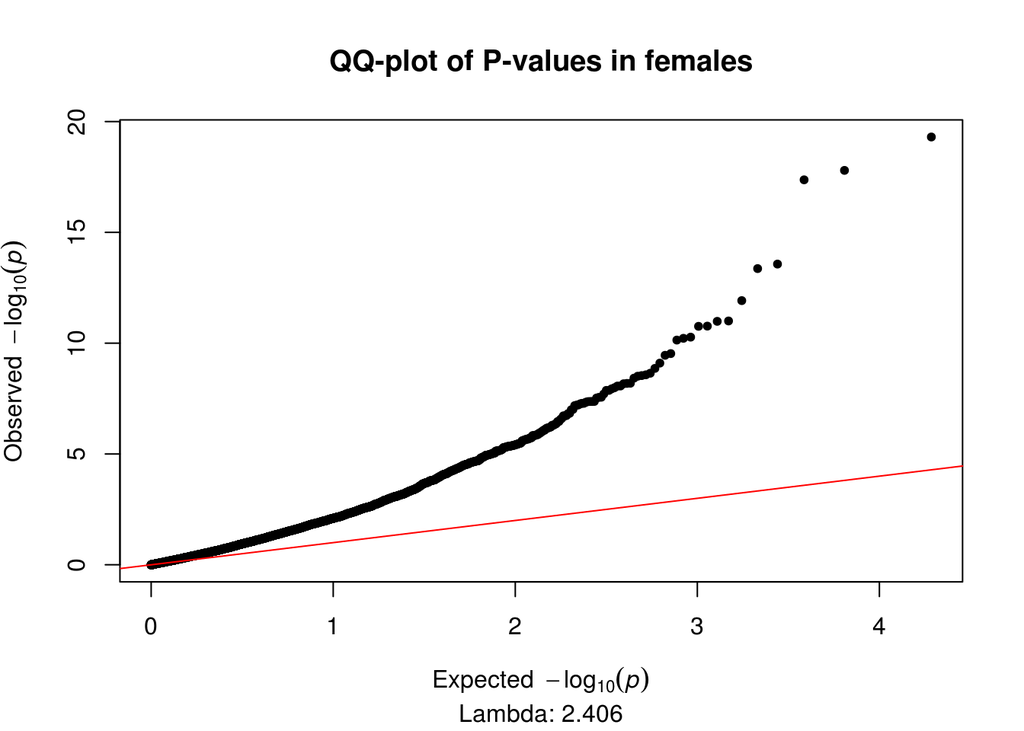